# Sentiment Analysis

author: “Mhairi McNeill”  
date: “27/08/2019”

# 1 Learning Objectives

- Understand what sentiment analysis is
- Know about the different sentiment lexicons available
- Be able to find the sentiment of words and do analysis using those sentiments.

**Duration - 1 hour 30 mins**

In this lesson you’ll be learning how to find the sentiment of words and of texts as a whole. Sentiment is the feelings demonstrated in the text. This can be as simple as positive/negative, or include emotions like fear, disgust and joy.

Sentiment analysis is not an exact science! The results you get may not make scene in context. Always treat any sentiment analysis with some scepticism.

# 2 Different sentiment lexicons

To start, load all the package we’ll be using in this lesson.

```r
library(tidytext)
library(harrypotter)
library(dplyr)
```

We’ll also need to install a package that gives us access to other sentiment lexicons, although we don’t have to load the package.

```r
install.packages("textdata")
```

One complication with sentiment analysis is that we have several options for sentiment *lexicons*. These are different lists of sentiment words and their associated sentiment.

The first we will see is called “afinn”. It gives numeric sentiment scores between -5 and 5.

```r
get_sentiments("afinn")
```

| word | value |
| --- | --- |
| abandon | -2 |
| abandoned | -2 |
| abandons | -2 |
| abducted | -2 |
| abduction | -2 |
| abductions | -2 |
| abhor | -3 |
| abhorred | -3 |
| abhorrent | -3 |
| abhors | -3 |

[output cut: 2467 more lines]

Note you will need to type `1` in the console, to download the sentiment dataset.

A simpler option is the bing sentiment lexicon, which only categorises sentiments as positive or negative.

```r
get_sentiments("bing")
```

| word | sentiment |
| --- | --- |
| 2-faces | negative |
| abnormal | negative |
| abolish | negative |
| abominable | negative |
| abominably | negative |
| abominate | negative |
| abomination | negative |
| abort | negative |
| aborted | negative |
| aborts | negative |

[output cut: 6776 more lines]

For more options you can use “loughran”.

```r
get_sentiments("loughran")
```

| word | sentiment |
| --- | --- |
| abandon | negative |
| abandoned | negative |
| abandoning | negative |
| abandonment | negative |
| abandonments | negative |
| abandons | negative |
| abdicated | negative |
| abdicates | negative |
| abdicating | negative |
| abdication | negative |

[output cut: 4140 more lines]

The categories available can be seen below.

```r
get_sentiments("loughran") %>%
  count(sentiment, sort = TRUE)
```

| sentiment | n |
| --- | --- |
| negative | 2355 |
| litigious | 904 |
| positive | 354 |
| uncertainty | 297 |
| constraining | 184 |
| superfluous | 56 |

There’s a fourth sentiment lexicon available called `"nrc"`, which has categorical sentiment scores. This dataset also allows words to display multiple sentiments. However, this is a very large sentiment dataset so we won’t be downloading it just now.

```r
# Can take a while to download
get_sentiments("nrc")
```

| word | sentiment |
| --- | --- |
| abacus | trust |
| abandon | fear |
| abandon | negative |
| abandon | sadness |
| abandoned | anger |
| abandoned | fear |
| abandoned | negative |
| abandoned | sadness |
| abandonment | anger |
| abandonment | fear |

[output cut: 9990 more lines]

For reference, here are the categories in nrc.

```r
get_sentiments("nrc") %>%
  count(sentiment, sort = TRUE)
```

| sentiment | n |
| --- | --- |
| negative | 3324 |
| positive | 2312 |
| fear | 1476 |
| anger | 1247 |
| trust | 1231 |
| sadness | 1191 |
| disgust | 1058 |
| anticipation | 839 |
| joy | 689 |
| surprise | 534 |

To find the sentiment of your words, all you need to do is join with one of these sentiment lexicons.

First let’s prepare data for the third Harry Potter book.

```r
book_3 <- tibble(
  text = prisoner_of_azkaban,
  chapter = 1:length(prisoner_of_azkaban)
) %>%
unnest_tokens(word, text) %>%
anti_join(stop_words)
```

Now if we want to add sentiments we can left join. Every sentiment word in `book_3` now has a sentiment attached.

```r
book_3 %>%
  left_join(get_sentiments("bing"))
```

| chapter | word | sentiment |
| --- | --- | --- |
| 1 | owl | NA |
| 1 | post | NA |
| 1 | harry | NA |
| 1 | potter | NA |
| 1 | highly | NA |
| 1 | unusual | negative |
| 1 | boy | NA |
| 1 | hated | negative |
| 1 | summer | NA |
| 1 | holidays | NA |

[output cut: 9990 more lines]

If you want to keep only the sentiment words, you can use an inner join.

```r
book_3 %>%
  inner_join(get_sentiments("bing"))
```

| chapter | word | sentiment |
| --- | --- | --- |
| 1 | unusual | negative |
| 1 | hated | negative |
| 1 | dead | negative |
| 1 | lying | negative |
| 1 | magic | positive |
| 1 | burning | negative |
| 1 | pointless | negative |
| 1 | top | positive |
| 1 | magic | positive |
| 1 | afraid | negative |

[output cut: 4927 more lines]

# 3 Most common positive, and most common negative words

As a really basic, first analysis let’s find the most common positive and most common negative words. First we create a new data frame with sentiments.

```r
book_3_sentiments <-
book_3 %>%
  inner_join(get_sentiments("bing"))
```

Then simply filter for positive to see the positive words, and count and sort.

```r
book_3_sentiments %>%
  filter(sentiment == "positive") %>%
  count(word, sort = TRUE)
```

| word | n |
| --- | --- |
| magic | 64 |
| happy | 37 |
| top | 35 |
| magical | 30 |
| fast | 28 |
| quiet | 25 |
| gold | 24 |
| free | 20 |
| ready | 20 |
| excellent | 18 |

[output cut: 379 more lines]

We can do the same for negative words.

```r
book_3_sentiments %>%
  filter(sentiment == "negative") %>%
  count(word, sort = TRUE)
```

| word | n |
| --- | --- |
| fudge | 100 |
| dark | 79 |
| slowly | 47 |
| fell | 45 |
| hard | 44 |
| dead | 39 |
| lost | 38 |
| cold | 36 |
| kill | 31 |
| fat | 27 |

[output cut: 834 more lines]

Here we can see some of the problems with word-based sentiment analysis. Here “fudge” is the most common negative word. While “fudge” can have a negative meaning (to fudge the numbers), it can also have a neutral meaning as a type of sweet. Which meaning do you think is most common in The Prisoner of Azkaban?

Another problem with word-based sentiment analysis is negation. While the word “well” is positive by itself, it has a negative meaning if combined with not. But since English is complicated the negation isn’t necessarily beside the word being negated. For example, look at this sentence:

“Word-based sentiment analysis does not perform well”.

> **Task - 10 minutes**

> Find the most common positive, negative and neutral words in the book “Goblet of Fire”. Use the “loughran” sentiment analysis dataset.

> **Solution**

> ```r
> book_4 <- tibble(
>   text = goblet_of_fire,
>   chapter = 1:length(goblet_of_fire)
> ) %>%
> unnest_tokens(word, text) %>%
> anti_join(stop_words)
> ```

> ```r
> book_4_sentiment <-
>   book_4 %>%
>   left_join(get_sentiments("loughran"))
> ```

> ```r
> book_4_sentiment %>%
>   filter(sentiment == "positive") %>%
>   count(word, sort = TRUE)
> ```

> | word | n |
> | --- | --- |
> | happy | 28 |
> | happily | 27 |
> | strong | 25 |
> | excellent | 23 |
> | excited | 22 |
> | win | 21 |
> | excitement | 20 |
> | easy | 18 |
> | dream | 17 |
> | leading | 16 |
>
> [output cut: 114 more lines]

> ```r
> book_4_sentiment %>%
>   filter(is.na(sentiment)) %>%
>   count(word, sort = TRUE)
> ```

> | word | n |
> | --- | --- |
> | harry | 2936 |
> | ron | 980 |
> | hermione | 826 |
> | dumbledore | 529 |
> | looked | 483 |
> | weasley | 370 |
> | hagrid | 326 |
> | eyes | 316 |
> | moody | 309 |
> | professor | 290 |
>
> [output cut: 9253 more lines]

> ```r
> book_4_sentiment %>%
>   filter(sentiment == "negative") %>%
>   count(word, sort = TRUE)
> ```

> | word | n |
> | --- | --- |
> | slowly | 84 |
> | stopped | 66 |
> | trouble | 50 |
> | miss | 47 |
> | shut | 43 |
> | bad | 40 |
> | closed | 40 |
> | wrong | 36 |
> | seized | 34 |
> | lost | 31 |
>
> [output cut: 419 more lines]

# 4 Average sentiment per chapter

Now lets look at a different sort of analysis. Let’s try to find the average sentiment in each chapter in the third Harry Potter book.

For this we’ll need to use the “afinn” sentiment lexicon, because this gives numeric scores.

```r
book_3_sentiments <-
  book_3 %>%
  inner_join(get_sentiments("afinn"))
```

Now it’s just a simple matter of using group by and summarise to find the average value in each chapter.

```r
chapter_sentiments <-
book_3_sentiments %>%
  group_by(chapter) %>%
  summarise(
    mean_sentiment = mean(value)
  )

chapter_sentiments
```

| chapter | mean_sentiment |
| --- | --- |
| 1 | 0.159420290 |
| 2 | -0.654088050 |
| 3 | -0.828947368 |
| 4 | 0.005952381 |
| 5 | -0.647368421 |
| 6 | -0.292968750 |
| 7 | -0.612500000 |
| 8 | -0.474860335 |
| 9 | -0.678160920 |
| 10 | -0.561797753 |

[output cut: 12 more lines]

We can use `ggplot2` to plot the average sentiment.

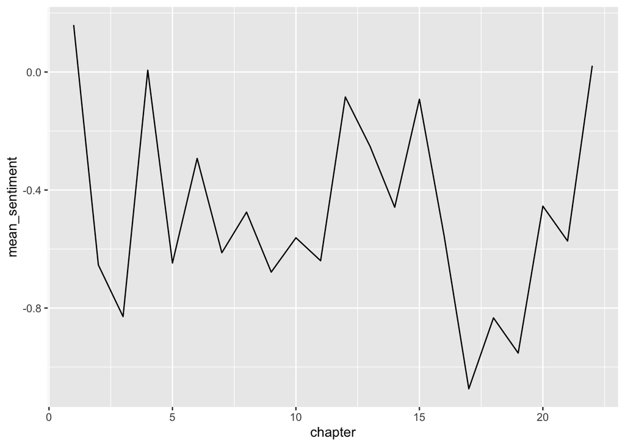

```r
library(ggplot2)

ggplot(chapter_sentiments) +
  aes(x = chapter, y = mean_sentiment) +
  geom_line()
```

The series of steps you just carried out is a very common pattern:

1. Use `tidytext` to turn text into data
2. Analyse and shape the data using `dplyr`
3. Plot the results using `ggplot2`.

> **Task - 5 minutes**

> Find average sentiment for each chapter of Goblet of Fire. However, this time we want non-sentiment words to count as zero in the average.

> **Solution**

> ```r
> book_4_sentiments <-
>   book_4 %>%
>   left_join(get_sentiments("afinn"))
> ```

> ```r
> book_4_chapter_sentiments <-
> book_4_sentiments %>%
>   mutate(
>     value = coalesce(value, 0)
>   ) %>%
>   group_by(chapter) %>%
>   summarise(
>     mean_sentiment = mean(value)
>   )
>
> book_4_chapter_sentiments
> ```

> | chapter | mean_sentiment |
> | --- | --- |
> | 1 | -0.1013605442 |
> | 2 | -0.0817307692 |
> | 3 | -0.0377978636 |
> | 4 | -0.1108394458 |
> | 5 | -0.0105932203 |
> | 6 | -0.0022624434 |
> | 7 | 0.0193517175 |
> | 8 | -0.0003996803 |
> | 9 | -0.0695067265 |
> | 10 | -0.0441298918 |
>
> [output cut: 27 more lines]

# 5 Recap

- Name a numeric sentiment lexicon

  **Solution**

  afinn
- Name three categorical sentiment lexicons

  **Solution**

  bing, loughran, nrc
- How do you add sentiment data to a data frame

  **Solution**

  By using a join